# Model sanity check

### m5: Time budget

Does time allocated to foraging differ between the social groups?

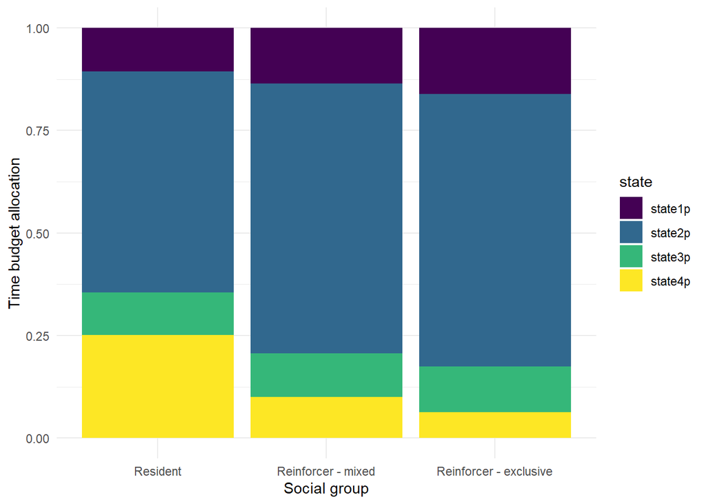

```r
# read in data and filter to reinforcement period
datam5 <- read.csv("results/daily_time_budget.csv") %>%
  # add metadata
  left_join(dplyr::select(metadata, c("id", "cohort"))) %>%
  # format dates as dates
  mutate(date = as_date(date_bird)) %>%
  # limit to reinforcement period
  filter(date %in% rein_dates) %>%
  # add a time elapsed post-release variable
  mutate(elapsed = as.numeric(date - as_date("2023-06-10"))) %>%
  # add column for membership to social group
  mutate(social = ifelse(id %in% club, "Reinforcer - exclusive", ifelse(cohort == "Resident", "Resident", "Reinforcer - mixed"))) %>%
  # convert group to factor and set resident as the intercept
  mutate(social = factor(social, levels = c("Resident", "Reinforcer - mixed", "Reinforcer - exclusive"))) %>%
  # add quadratic term for time
  mutate(elapsed2 = elapsed^2)

# create social group means
sum5 <- datam5 %>%
  group_by(date, social) %>%
  summarise(dist = mean(state2p),
            upper = dist + std.error(state2p),
            lower = dist - std.error(state2p)) %>%
  arrange(date)

# and pivot longer for barchart
datam5bar <- datam5 %>%
  select(!3:7) %>%
  pivot_longer(3:6, names_to = "state", values_to = "proportion")

# plot time budget by social group
ggplot(datam5bar)+
  geom_bar(aes(x = social, y = proportion, fill = state),
           position="fill", stat="identity")+
  xlab("Social group")+
  ylab("Time budget allocation")+
  theme_minimal()+
  scale_fill_viridis_d()
```

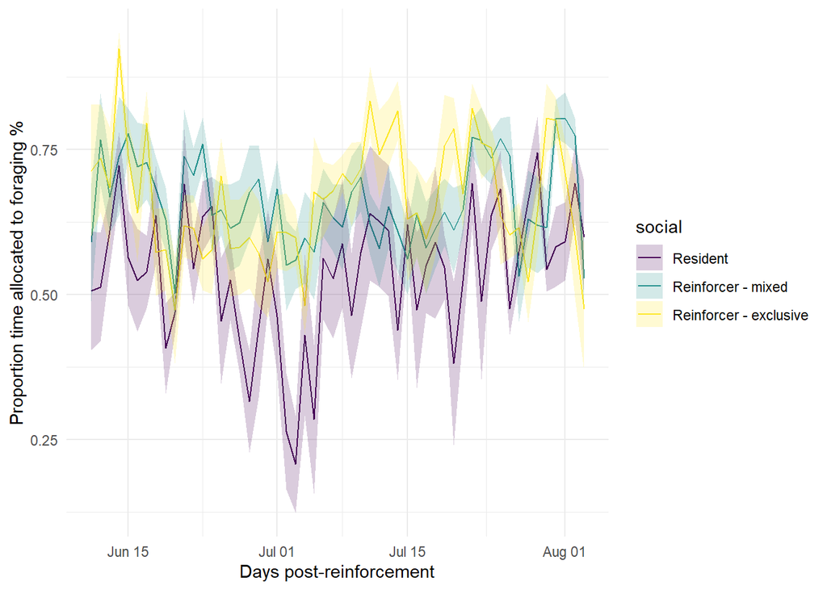

```r
# plot distance from release site over time as social group means
ggplot(sum5, aes(date, dist, ymin = lower, ymax = upper)) +
  geom_path(aes(colour = social)) +
  geom_ribbon(aes(fill = social), alpha = 0.2) +
  xlab("Days post-reinforcement") +
  ylab("Proportion time allocated to foraging %") +
  theme_minimal() +
  scale_fill_viridis_d()+
  scale_colour_viridis_d()
```

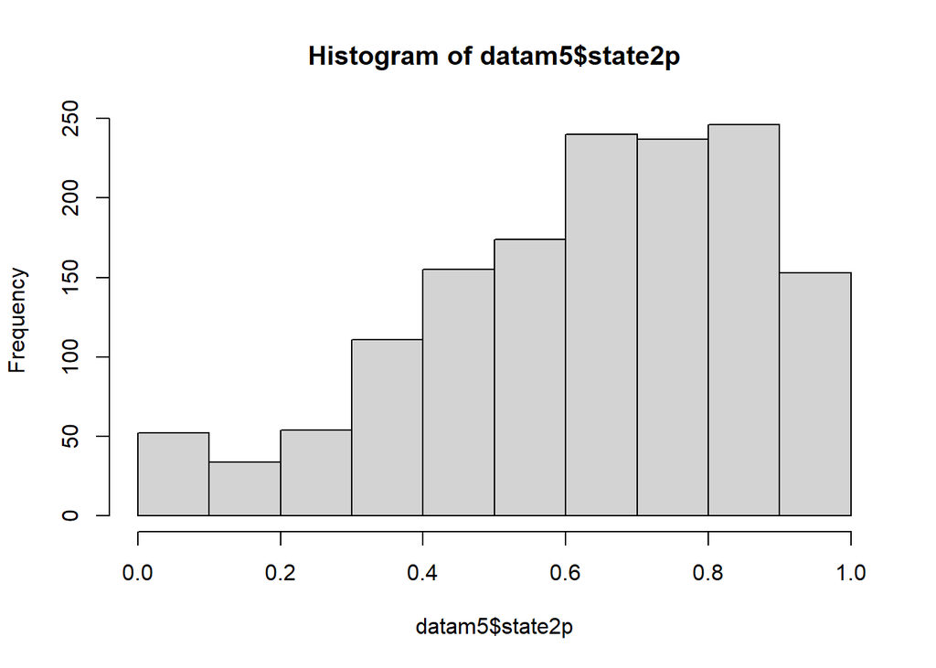

```r
# distribution of allocation
hist(datam5$state2p)
```

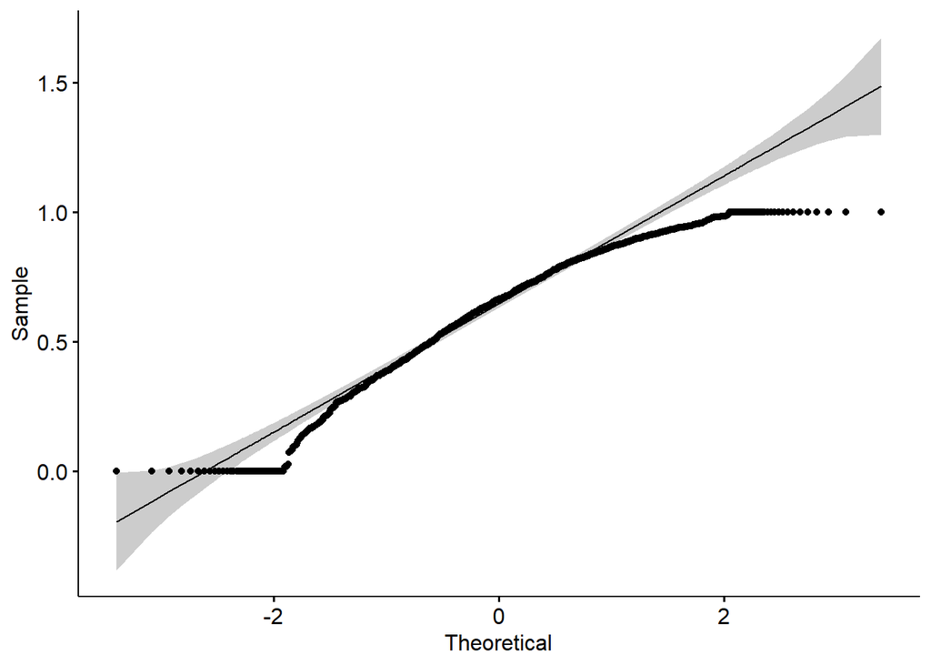

```r
ggqqplot(datam5$state2p)
```

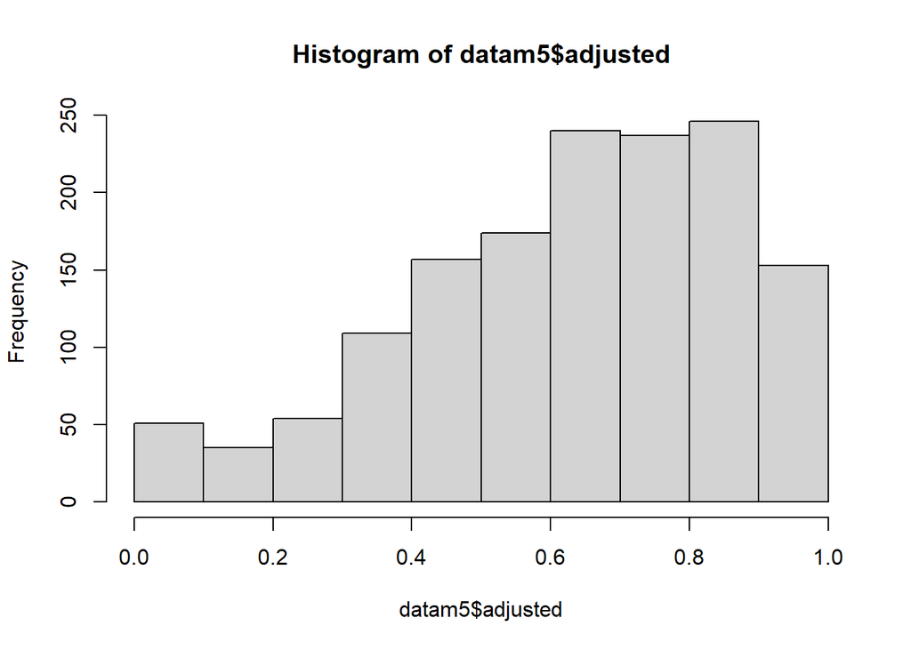

```r
# Adjust values slightly so that 0 < x < 1
datam5 <- datam5 %>%
  mutate(adjusted = (state2p + 0.001) / 1.002)

hist(datam5$adjusted)
```

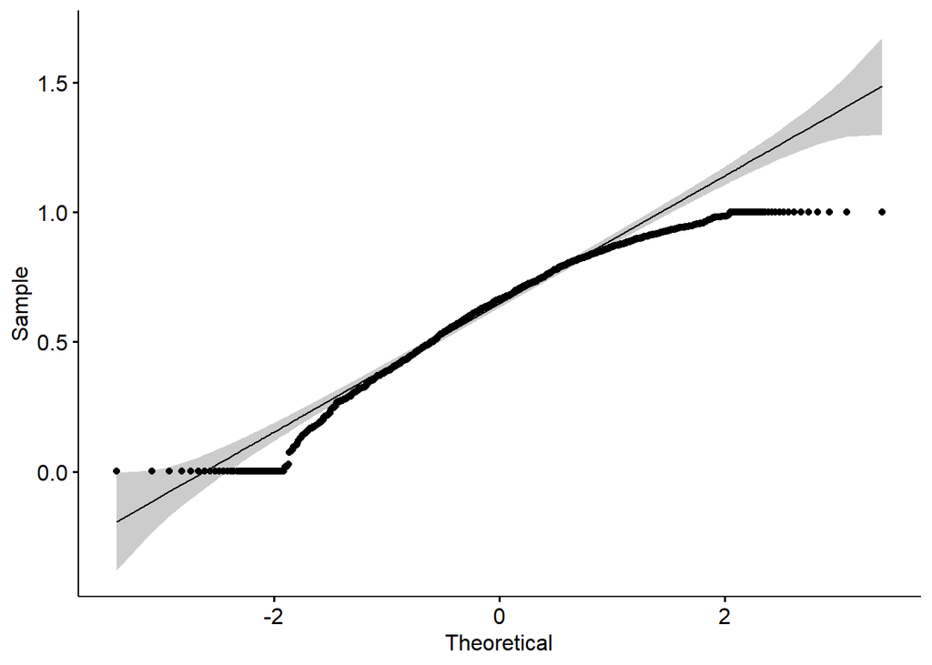

```r
ggqqplot(datam5$adjusted)
```

```r
# test difference between the groups with interaction of time as a quadratic
m5 <- glmmTMB(adjusted ~ social * (scale(elapsed) + scale(elapsed2))+ (1|id),
              data = datam5,
              family = beta_family(link = "logit"),
              na.action = "na.fail")

# model selection
dm5 <- dredge(m5)

# print best model on AICc
best5 <- get.models(dm5, delta==0)[[1]]
summary(best5)
```

```
##  Family: beta  ( logit )
## Formula:
## adjusted ~ scale(elapsed) + scale(elapsed2) + social + (1 | id) +
##     scale(elapsed):social + scale(elapsed2):social
## Data: datam5
##
##      AIC      BIC   logLik deviance df.resid
##   -507.3   -449.2    264.6   -529.3     1445
##
## Random effects:
##
## Conditional model:
##  Groups Name        Variance Std.Dev.
##  id     (Intercept) 0.1217   0.3489
## Number of obs: 1456, groups:  id, 28
##
## Dispersion parameter for beta family (): 2.98
##
## Conditional model:
##                                              Estimate Std. Error z value
## (Intercept)                                  -0.09401    0.13429  -0.700
## scale(elapsed)                               -1.08603    0.21093  -5.149
## scale(elapsed2)                               1.23691    0.21030   5.882
## socialReinforcer - mixed                      0.67468    0.17573   3.839
## socialReinforcer - exclusive                  0.79048    0.18348   4.308
## scale(elapsed):socialReinforcer - mixed       0.35398    0.26978   1.312
## scale(elapsed):socialReinforcer - exclusive   0.56882    0.27556   2.064
## scale(elapsed2):socialReinforcer - mixed     -0.55428    0.27006  -2.052
## scale(elapsed2):socialReinforcer - exclusive -0.71888    0.27680  -2.597
##                                              Pr(>|z|)
## (Intercept)                                  0.483928
## scale(elapsed)                               2.62e-07 ***
## scale(elapsed2)                              4.07e-09 ***
## socialReinforcer - mixed                     0.000123 ***
## socialReinforcer - exclusive                 1.65e-05 ***
## scale(elapsed):socialReinforcer - mixed      0.189485
## scale(elapsed):socialReinforcer - exclusive  0.038995 *
## scale(elapsed2):socialReinforcer - mixed     0.040128 *
## scale(elapsed2):socialReinforcer - exclusive 0.009401 **
## ---
## Signif. codes:  0 '***' 0.001 '**' 0.01 '*' 0.05 '.' 0.1 ' ' 1
```

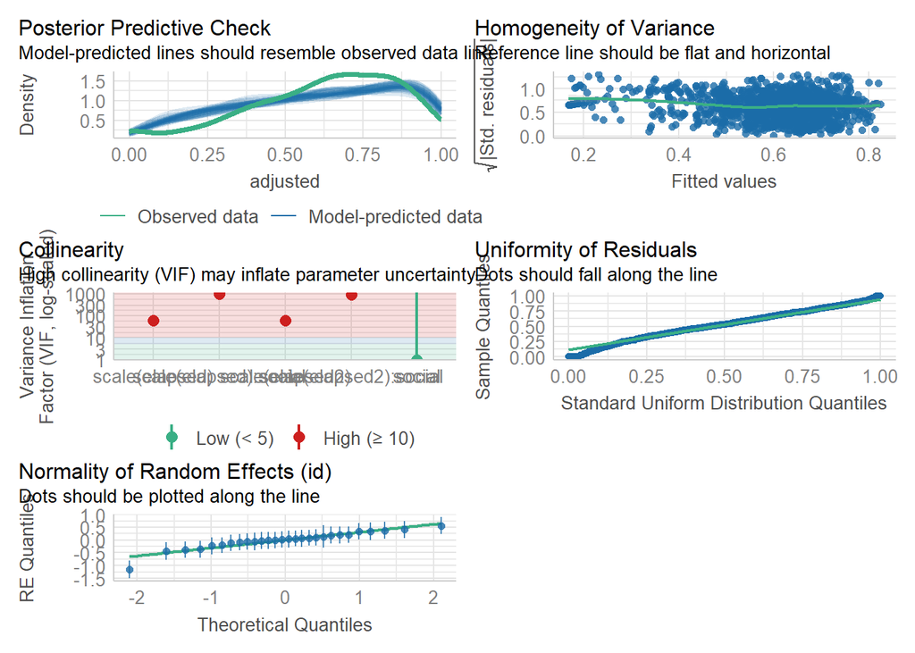

```r
# check model
check_model(best5)
```

```r
# post-hoc comparison of means
emmeans(best5, pairwise ~ social, type = "response")
```

```
## $emmeans
##  social                 response     SE  df asymp.LCL asymp.UCL
##  Resident                  0.477 0.0335 Inf     0.412     0.542
##  Reinforcer - mixed        0.641 0.0261 Inf     0.589     0.691
##  Reinforcer - exclusive    0.667 0.0278 Inf     0.611     0.719
##
## Confidence level used: 0.95
## Intervals are back-transformed from the logit scale
##
## $contrasts
##  contrast                                        odds.ratio     SE  df null
##  Resident / (Reinforcer / mixed)                      0.509 0.0895 Inf    1
##  Resident / (Reinforcer / exclusive)                  0.454 0.0832 Inf    1
##  (Reinforcer / mixed) / (Reinforcer / exclusive)      0.891 0.1500 Inf    1
##  z.ratio p.value
##   -3.839  0.0004
##   -4.308  <.0001
##   -0.688  0.7708
##
## P value adjustment: tukey method for comparing a family of 3 estimates
## Tests are performed on the log odds ratio scale
```

```r
# post-hoc comparison of slopes
emtrends(best5, pairwise ~ social, var = "elapsed")
```

```
## $emtrends
##  social                 elapsed.trend     SE  df asymp.LCL asymp.UCL
##  Resident                     -0.0697 0.0135 Inf   -0.0962   -0.0431
##  Reinforcer - mixed           -0.0470 0.0108 Inf   -0.0682   -0.0258
##  Reinforcer - exclusive       -0.0332 0.0114 Inf   -0.0555   -0.0109
##
## Confidence level used: 0.95
##
## $contrasts
##  contrast                                        estimate     SE  df z.ratio
##  Resident - (Reinforcer - mixed)                  -0.0227 0.0173 Inf  -1.312
##  Resident - (Reinforcer - exclusive)              -0.0365 0.0177 Inf  -2.064
##  (Reinforcer - mixed) - (Reinforcer - exclusive)  -0.0138 0.0157 Inf  -0.878
##  p.value
##   0.3884
##   0.0974
##   0.6543
##
## P value adjustment: tukey method for comparing a family of 3 estimates
```

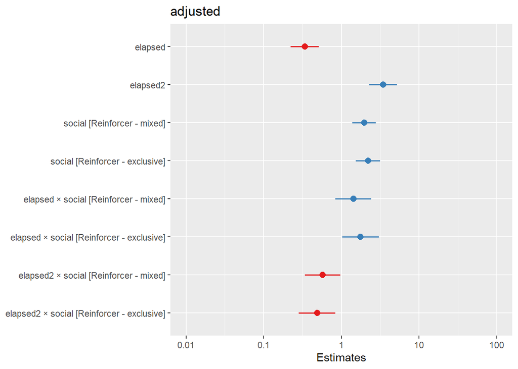

```r
# plot effects
plot_model(best5)
```

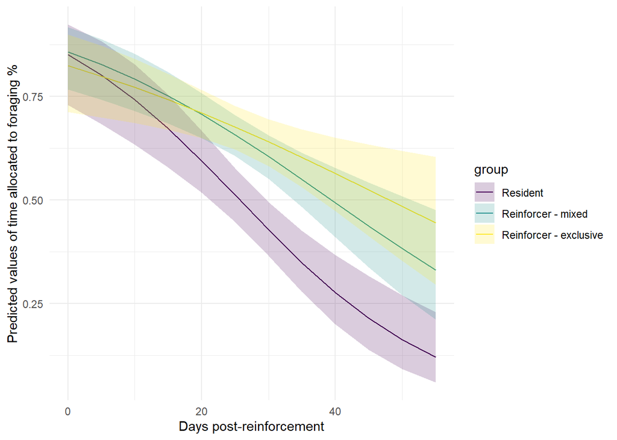

```r
# marginal effects
pred5 <- predict_response(best5, terms = c("elapsed", "social"),
                          bias_correction = TRUE)

# plot predictions
ggplot(pred5, aes(x, predicted, fill = group, ymin = conf.low, ymax = conf.high)) +
  geom_line(aes(colour = group))+
  geom_ribbon(alpha = 0.2)+
  xlab("Days post-reinforcement") +
  ylab("Predicted values of time allocated to foraging %") +
  theme_minimal()+
  scale_fill_viridis_d()+
  scale_colour_viridis_d()
```

**Results:**

Time allocated to foraging declines over time (estimate = -1.08603, se = 0.21093, p < 0.0001) but is non-linear, with a deceleration of the decline (estimate = 1.23691, se = 0.21030, p < 0.0001).

The reinforcer groups (both mixed and exclusive) are more likely to exhibit higher foraging allocation (mean 64% for mixed and 67% for exclusive) than the residents(mean 47%), with exclusive reinforcers showing the strongest effect (p < 0.0001). Exclusive reinforcers experience a less negative effect of elapsed time (estimate = 0.56882, se = 0.27556, p = 0.0390), particularly in the quadratic term (estimate = -0.71888, se = 0.27680, p = 0.0094), suggesting a more stable foraging allocation than the residents. Whereas the mixed reinforcers trend towards the residents.

**Interpretation:** Mixed reinforcers trend towards the residents, potentially because of improved foraging efficiency over time. Whereas the exclusive reinforcers maintain a higher allocation towards foraging, potentially because of less efficiency or foraging in less productive areas. Both reinforcers have higher allocations than the residents , probably because residents have overall better foraging efficiency.

The decreasing trend may be associated with seasonal food availability. The release took place in winter, so theoretically food supply should increase as winter transitioned to Spring. Indeed all birds initially allocated more than three-quarters of their time to foraging, but this declined by August to less than a quarter for residents and less than half for reinforcers.

### m6: Weight change

In addition to the movement-based metrics of performance I wanted to look at health check data. Weight change post-release is a good indicator of performance, where some loss is expected but less steep decline (trending towards stability) indicates better performance.

We were unable to compare residents to reinforcers for weight change because we did not have weight measurements for the six individuals released in January 2023 (backpacks fitted in the December trip and released by Mt Rothwell staff rather than me going back down there). So we can only compare reinforcers, but interested to see how the social group memberships contrast.

Unlike the movement data, the study period is for 70 days because weights were taken after the 55 minimum common tracking period.

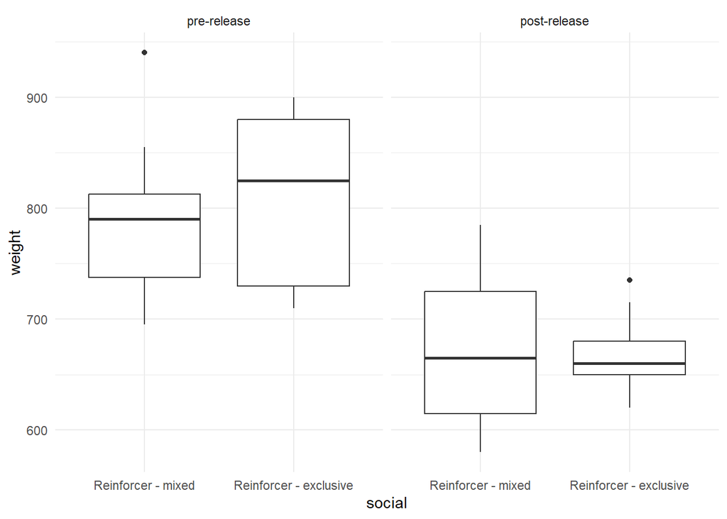

```r
# read in data and clean up
datam6 <- read_xlsx("data/healthchecks.xlsx") %>%
  clean_names() %>%
  rename(id = identity) %>%
  select(id, date, weight) %>%
  # add metadata
  left_join(select(metadata, c(id, start_date, cohort))) %>%
  drop_na() %>%
  # format dates
  mutate(date = as_date(date),
         start_date = as_date(start_date)) %>%
  # calculate elapsed time and add status
  mutate(elapsed = as.numeric(date - start_date)) %>%
  # keep only reinforcers
  filter(cohort == "Reinforcing") %>%
  # add social group membership %>%
   mutate(social = as_factor(ifelse(id %in% club, "Reinforcer - exclusive", ifelse(cohort == "Resident", "Resident", "Reinforcer - mixed")))) %>%
  # keep only the latest pre-release values and assign to pre/post release
  group_by(id) %>%
  filter(elapsed > 0 | elapsed == max(elapsed[elapsed <= 0])) %>%
  ungroup() %>%
  mutate(status = as_factor(ifelse(elapsed > 0, "post-release", "pre-release"))) %>%
  arrange(id) %>%
  # filter to study period
  filter(elapsed <70)

# plot weight pre and post-release
ggplot(datam6)+
  geom_boxplot(aes(social, weight))+
  theme_minimal()+
  facet_wrap(~status)
```

We have pre and post data for 18 of the 20 reinforcers. All lost weight. The mixed social group started out on average lower than the exclusive group.

Next I calculated the change in weight both in grams and as a proportion of starting weight (to account for variation in body sizes).

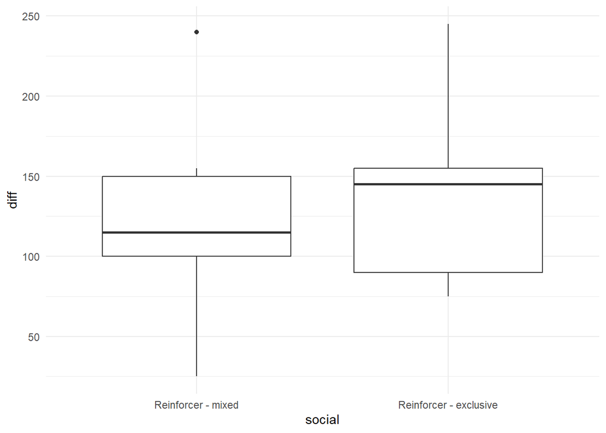

```r
# calculate weight change in grams and as a proportion of starting weight
sum6 <- datam6 %>%
  select(c(id, social, weight, status)) %>%
  pivot_wider(names_from = status, values_from = weight) %>%
  clean_names() %>%
  drop_na() %>%
  # add change columns
  mutate(diff = pre_release - post_release,
         proportion = diff/pre_release) %>%
  # format social group as factor
  mutate(social = as_factor(social))

# plot total weight differences by social group
ggplot(sum6)+
  geom_boxplot(aes(social, diff))+
  theme_minimal()
```

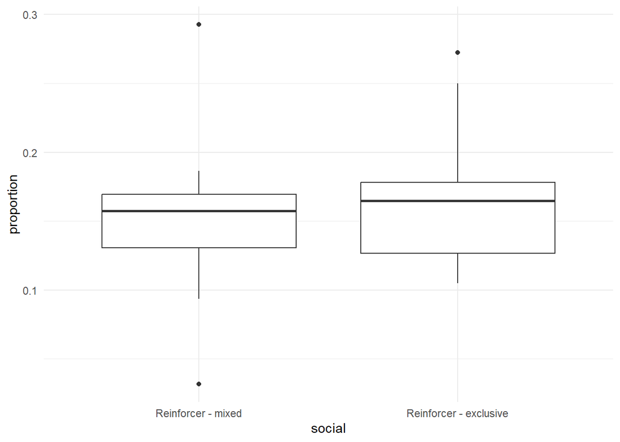

```r
# plot proportional weight differences by social group
ggplot(sum6)+
  geom_boxplot(aes(social, proportion))+
  theme_minimal()
```

Although total weight change seems on average lower in the mixed group, proportionally it does not look like a lot of difference.

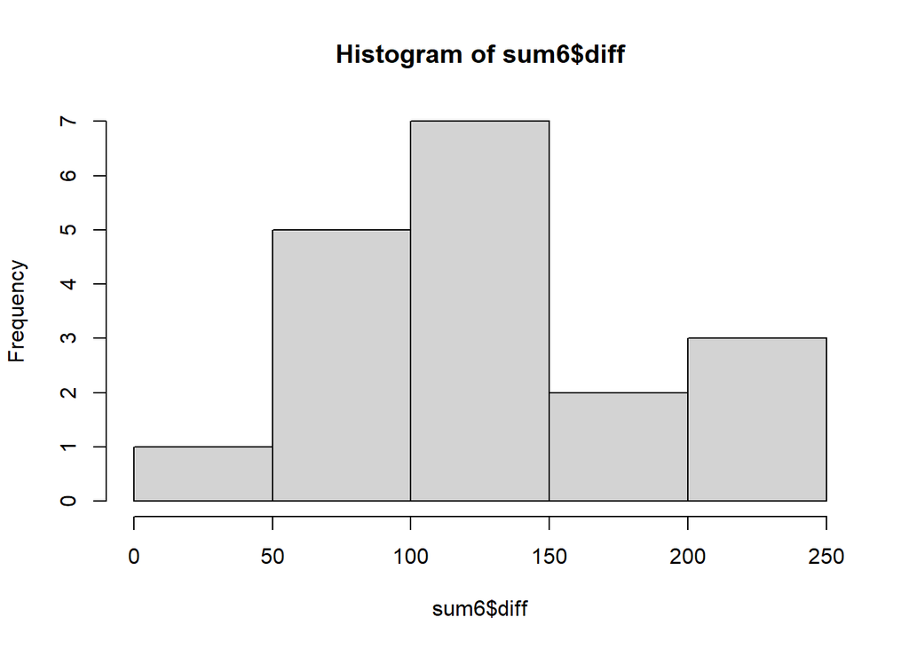

```r
# check distribution of the difference
hist(sum6$diff)
```

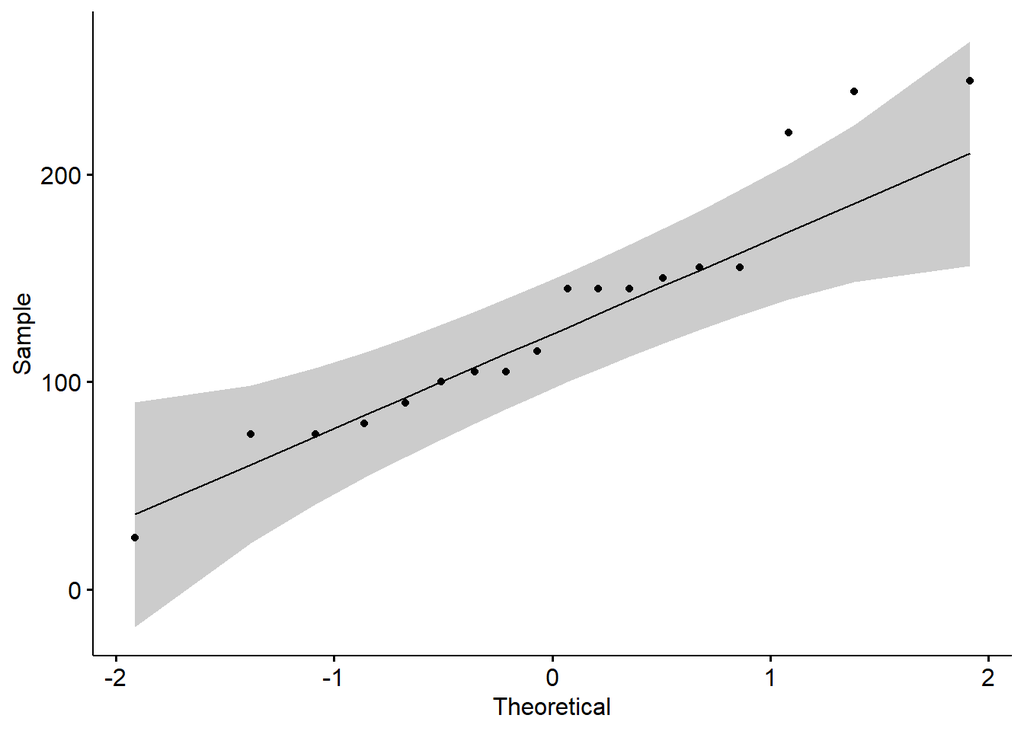

```r
ggqqplot(sum6$diff)
```

```r
# test whether weight change differs between the social groups
# as total difference
m6a <- glmmTMB(diff ~ social, data = sum6)
summary(m6a)
```

```
##  Family: gaussian  ( identity )
## Formula:          diff ~ social
## Data: sum6
##
##      AIC      BIC   logLik deviance df.resid
##    202.5    205.2    -98.2    196.5       15
##
##
## Dispersion estimate for gaussian family (sigma^2): 3.22e+03
##
## Conditional model:
##                              Estimate Std. Error z value Pr(>|z|)
## (Intercept)                    123.33      18.92   6.518 7.12e-11 ***
## socialReinforcer - exclusive    16.67      26.76   0.623    0.533
## ---
## Signif. codes:  0 '***' 0.001 '**' 0.01 '*' 0.05 '.' 0.1 ' ' 1
```

```r
# and as a proportion of starting weight
m6b <- glmmTMB(proportion ~ social, data = sum6)
summary(m6b)
```

```
##  Family: gaussian  ( identity )
## Formula:          proportion ~ social
## Data: sum6
##
##      AIC      BIC   logLik deviance df.resid
##    -43.4    -40.7     24.7    -49.4       15
##
##
## Dispersion estimate for gaussian family (sigma^2): 0.00377
##
## Conditional model:
##                              Estimate Std. Error z value Pr(>|z|)
## (Intercept)                   0.15302    0.02046   7.478 7.54e-14 ***
## socialReinforcer - exclusive  0.01542    0.02894   0.533    0.594
## ---
## Signif. codes:  0 '***' 0.001 '**' 0.01 '*' 0.05 '.' 0.1 ' ' 1
```

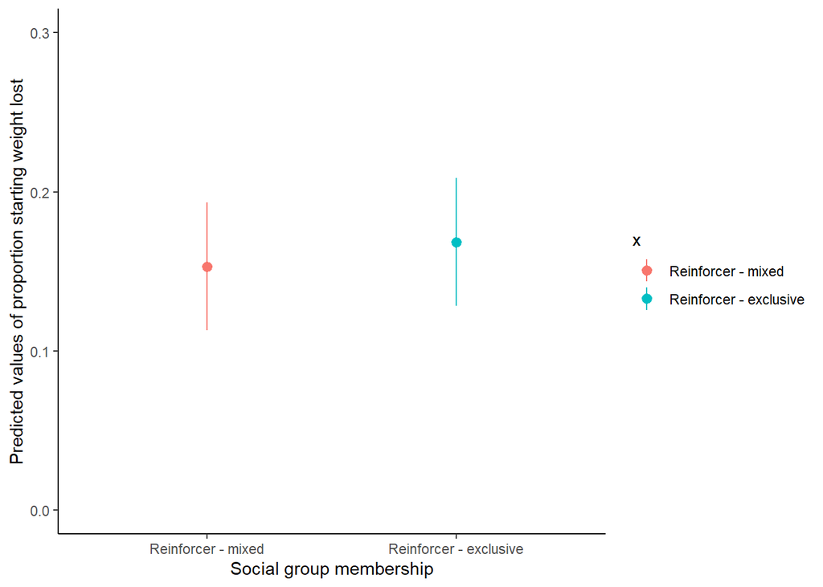

```r
# predictions
pred6b <- predict_response(m6b, terms = c("social"))

# plot predictions
ggplot(pred6b, aes(x, predicted, colour = x))+
  geom_pointrange(aes(ymin = conf.low, ymax = conf.high))+
  xlab("Social group membership") +
  ylab("Predicted values of proportion starting weight lost")+
  theme_classic()+
  scale_y_continuous(limits = c(0, 0.3))
```

There is no significant differences between groups for weight loss.

I want to model predicted effects of overall weight change so I can model a geom_line of pre and post translocation (I think the geom_pointrange looks boring).

```r
# weight change over time between social groups
m6 <- glmmTMB(weight ~ social * status, data = datam6)
summary(m6)
```

```
##  Family: gaussian  ( identity )
## Formula:          weight ~ social * status
## Data: datam6
##
##      AIC      BIC   logLik deviance df.resid
##    433.2    441.4   -211.6    423.2       33
##
##
## Dispersion estimate for gaussian family (sigma^2): 4.02e+03
##
## Conditional model:
##                                                 Estimate Std. Error z value
## (Intercept)                                       785.91      19.13   41.09
## socialReinforcer - exclusive                       24.65      28.51    0.86
## statuspost-release                               -108.69      28.51   -3.81
## socialReinforcer - exclusive:statuspost-release   -31.31      41.31   -0.76
##                                                 Pr(>|z|)
## (Intercept)                                      < 2e-16 ***
## socialReinforcer - exclusive                    0.387318
## statuspost-release                              0.000138 ***
## socialReinforcer - exclusive:statuspost-release 0.448501
## ---
## Signif. codes:  0 '***' 0.001 '**' 0.01 '*' 0.05 '.' 0.1 ' ' 1
```

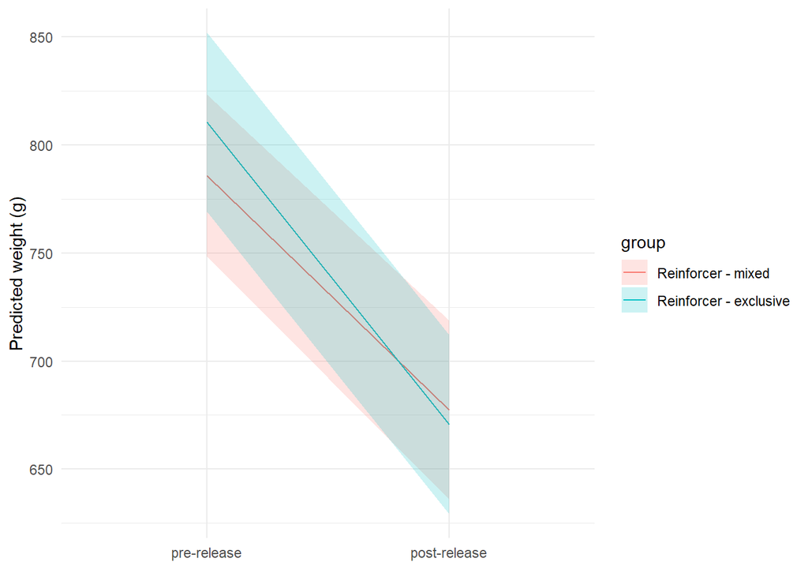

```r
# predictions
pred6 <- predict_response(m6, terms = c("status", "social"))

# plot predictions
ggplot(pred6, aes(x, predicted, fill = group, ymin = conf.low, ymax = conf.high, group = group)) +
  geom_line(aes(colour = group))+
  geom_ribbon(alpha = 0.2)+
  xlab(element_blank())+
  ylab("Predicted weight (g)") +
  theme_minimal()
```

Significant effect of time.

## Figures

Multi-plot of predicted values for all PRBM metrics by social group over time.

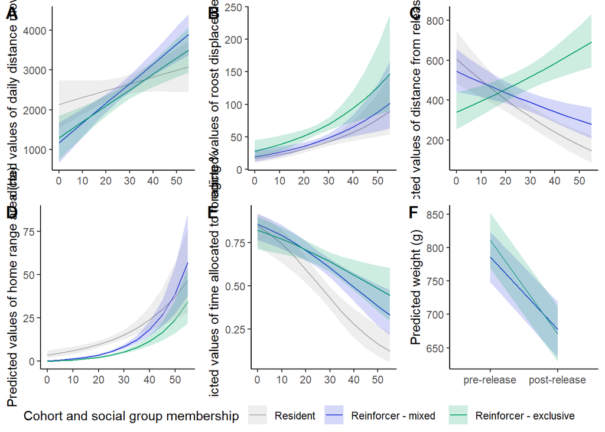

```r
# set default theme options for all plots
pal <- c("#AFACAC","#2E3EDC", "#07A567")

theme <- function(){
  list(
    geom_line(aes(colour = group)),
    geom_ribbon(alpha = 0.2),
    theme_classic(),
    xlab(element_blank()),
    scale_x_continuous(breaks=seq(0, 50, 10)),
    scale_color_manual(values = pal,
                       name = "Cohort and social group membership"),
    scale_fill_manual(values = pal,,
                      name = "Cohort and social group membership")
  )
}

# list of plots
g1 <- ggplot(pred1, aes(x, predicted, fill = group, ymin = conf.low, ymax = conf.high)) +
  xlab("Days post-reinforcement") +
  ylab("Predicted values of daily distance moved (m)")+
  theme()

g2 <- ggplot(pred2, aes(x, predicted, fill = group, ymin = conf.low, ymax = conf.high)) +
  xlab("Days post-reinforcement") +
  ylab("Predicted values of roost displacement (m)")+
  theme()

g3 <- ggplot(pred3, aes(x, predicted, fill = group, ymin = conf.low, ymax = conf.high)) +
  xlab("Days post-reinforcement") +
  ylab("Predicted values of distance from release site (m)")+
  theme()

g4 <- ggplot(pred4, aes(x, predicted, fill = group, ymin = conf.low, ymax = conf.high)) +
  xlab("Days post-reinforcement") +
  ylab("Predicted values of home range area (ha)")+
  theme()

g5 <- ggplot(pred5, aes(x, predicted, fill = group, ymin = conf.low, ymax = conf.high)) +
  xlab("Days post-reinforcement") +
  ylab("Predicted values of time allocated to foraging %")+
  theme()

g6 <- ggplot(pred6, aes(x, predicted, fill = group,
                        ymin = conf.low, ymax = conf.high, group = group)) +
  geom_line(aes(colour = group))+
  geom_ribbon(alpha = 0.2)+
  theme_classic()+
  xlab(element_blank())+
  ylab("Predicted weight (g)") +
  scale_colour_manual(values = c("#2E3EDC", "#07A567"))+
  scale_fill_manual(values = c("#2E3EDC", "#07A567"))

# multi plot 3x2
ggarrange(g1, g2, g3, g4, g5, g6,
          ncol = 3, nrow = 2,
          labels = c("A", "B", "C", "D", "E", "F"),
          common.legend = TRUE, legend = "bottom")
```

Multi plot of all effects.

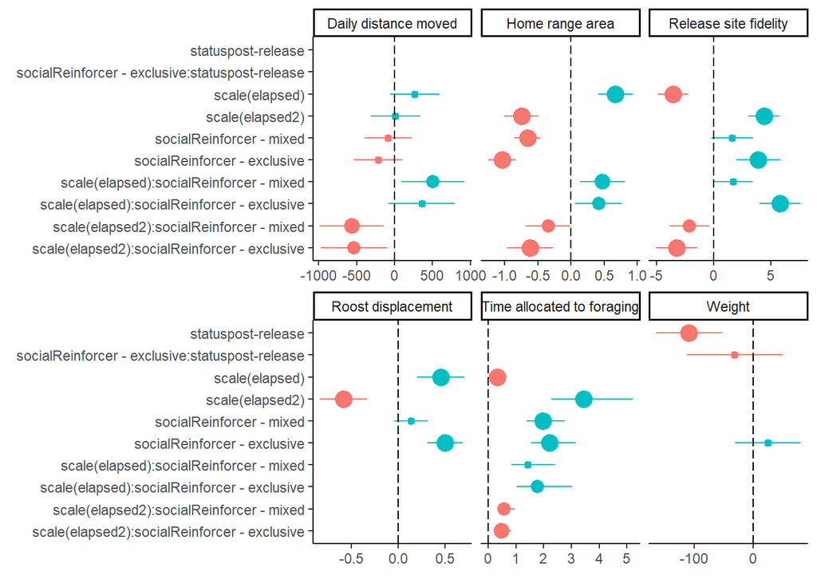

```r
# effects
e1 <- plot_model(best1)[["data"]] %>%
  mutate(variable = "Daily distance moved")

e2 <- plot_model(best2)[["data"]] %>%
  mutate(variable = "Roost displacement")

e3 <- plot_model(best3)[["data"]] %>%
  mutate(variable = "Release site fidelity")

e4 <- plot_model(best4)[["data"]] %>%
  mutate(variable = "Home range area")

e5 <- plot_model(best5)[["data"]] %>%
  mutate(variable = "Time allocated to foraging")

e6 <- plot_model(m6)[["data"]] %>%
  mutate(variable = "Weight")

# combine effects
effects <- rbind(e1, e2, e3, e4, e5, e6) %>%
  # add column for point size by strength of evidence (p values)
  mutate(strength  = ifelse(p.stars == "*", 2,
                            ifelse(p.stars == "**", 3,
                                   ifelse(p.stars == "***", 4, 1))))

# plot effects
ggplot(effects)+
  geom_pointrange(aes(estimate, term,
                      xmin = conf.low, xmax = conf.high,
                      size = strength, colour = group),
                  show.legend = FALSE)+
  geom_vline(xintercept=c(0), linetype="longdash")+
  facet_wrap(~variable, scales = "free_x")+
  scale_size_continuous(range = c(0.3, 1))+
  xlab(element_blank())+
  ylab(element_blank())+
  theme_classic()
```

The y labels are super messy - would appreciate some advice on how to make this not look like garbage.